← Back to the hackathon home

Topic 6 of 18

# DHIS2 Data Sets

Step by Step Guide: Building the Data Set and Testing Data Entry

**Purpose of this guide**

With the data elements and category combinations in place, this guide builds the data set that becomes the reporting form, and then tests it through data entry. Before you start, log in and open the Maintenance app as shown in Topic 1. After completing each step, insert a screenshot of your DHIS2 screen in the screenshot area.

Step 1: Create the Data Set

Create the dataset that will contain all the data elements for the reporting form.

Click: Data Sets → + New

**Example:**  
Name: Monthly Malaria Service Reporting  
Short Name: Malaria Monthly  
Period Type: Monthly  
Description: Monthly reporting of malaria services and outcomes

**Expected result:** The dataset is created and available for configuration.

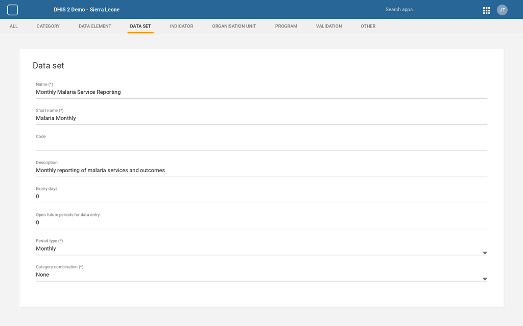

123456

**Figure 1.** The data set form. *This picture was drawn for the guide to show what the screen looks like. Your screen will show your own names and dates.*

1. 1**Name (*).** The full name of the data set. It appears in the data entry app.
2. 2**Short name (*).** A shorter name used in reports.
3. 3**Description.** What the data set is for.
4. 4**Expiry days and open future periods.** Leave both at 0 while you are testing.
5. 5**Period type (*).** Monthly, because facilities report once a month.
6. 6**Category combination (*).** None for the data set itself. The breakdown sits on the data elements.

Step 2: Add Data Elements to the Data Set

Add all the data elements that belong to the reporting dataset.

Open the Data Set → Configure/Edit data elements → Add the required data elements

### Recommended order

1. Malaria Testing
2. Malaria Results
3. Treatment
4. Outcomes

**Expected result:** All required data elements are associated with the dataset.

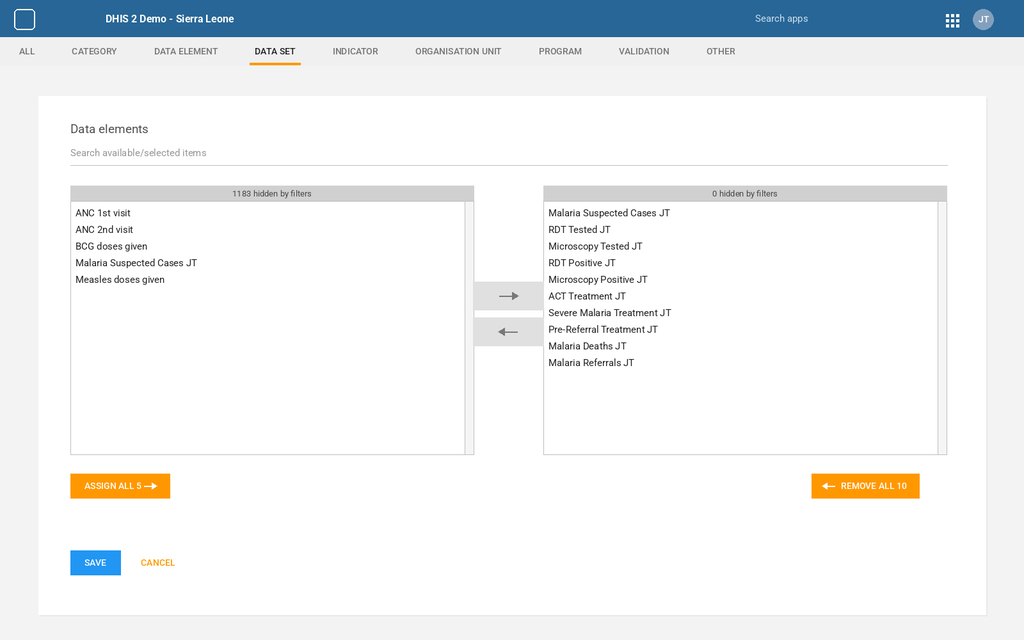

1234567

**Figure 2.** The ten data elements moved into the data set. *This picture was drawn for the guide to show what the screen looks like. Your screen will show your own names and dates.*

1. 1**Search.** Type part of a name to shorten the list.
2. 2**Available data elements.** Everything in the system that is not in this data set yet.
3. 3**Arrow buttons.** Move the selected data element across, or back.
4. 4**Selected data elements.** The ten malaria data elements that belong to this form.
5. 5**ASSIGN ALL.** Moves everything on the left across. Do not use it here.
6. 6**REMOVE ALL.** Clears the right hand list, if you need to start again.
7. 7**SAVE.** Saves the data set with its data elements.

Step 3: Assign the Data Set to Organisation Units

Assign the dataset to the organisation units that are expected to submit reports.

Open Data Set → Organisation Units → Select the reporting organisation units

**Example:**  
Sierra Leone → Bo District → Selected Health Facilities

**Expected result:** The dataset becomes available for data entry at the assigned organisation units.

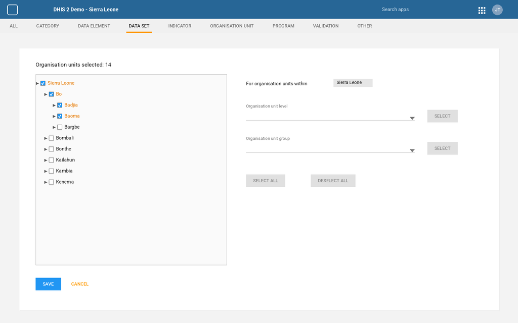

12345

**Figure 3.** Choosing the facilities that report this data set. *This picture was drawn for the guide to show what the screen looks like. Your screen will show your own names and dates.*

1. 1**Count.** How many organisation units are ticked.
2. 2**The tree.** Click the small arrow to open a district, then tick the facilities that report.
3. 3**Level and group.** Tick every unit at one level, or in one group, in one click.
4. 4**SELECT ALL.** Ticks the whole country. Use it only when every facility reports.
5. 5**SAVE.** Saves the assignment.

Step 4: Create Sections

Organise the dataset into logical sections so that the final data-entry form is easy to use.

Data set list → row menu → Manage sections → blue plus button

**Suggested sections:**  
1. Reporting Information  
2. Malaria Testing  
3. Malaria Results  
4. Treatment  
5. Outcomes

**Expected result:** The dataset is divided into clear reporting sections.

[figure not shown]

123456

**Figure 4.** The row menu of the data set, where Manage sections lives.

1. 1**DATA SET tab.** The orange line shows the tab you are on.
2. 2**Search.** Type part of the name to find your data set quickly.
3. 3**Your data set.** Monthly Malaria Service Reporting.
4. 4**Form type.** Default until sections exist. It changes to Section once you add them.
5. 5**Row menu.** The three dots at the end of the row.
6. 6**Manage sections.** Opens the section list for this data set. The same menu holds Edit compulsory data elements and Sharing settings, which we use in Steps 6 and 8.

[figure not shown]

1234

**Figure 5.** The section list, still empty.

1. 1**Data set section management.** The back arrow returns to the data set list.
2. 2**The data set.** The sections you make here belong to this data set only.
3. 3**Name column.** Your sections appear here, in the order they will show on the form.
4. 4**Blue plus button.** Opens the Add section window.

[figure not shown]

12345678

**Figure 6.** The Add section window. *The data element names in this picture were changed to the ten you created, so the guide stays consistent.*

1. 1**Name (*).** The heading users will see on the form, such as Malaria Testing.
2. 2**Code.** Optional. A short code such as mal_test.
3. 3**Description.** Optional. A note about what belongs in the section.
4. 4**Totals and grouping.** Leave all three boxes unticked for a simple form.
5. 5**Category combo filter.** Leave it as No filter, so every data element is offered.
6. 6**Search.** Type part of a name to shorten the list below.
7. 7**Data elements.** The two lists where you choose the fields of this section.
8. 8**SAVE.** Saves the section. CANCEL closes the window without saving.

Step 5: Add Data Elements to Each Section

Select the appropriate data elements for each section and arrange them in the order in which users should report the information.

**Example — Malaria Testing:**  
Suspected malaria cases  
RDT tested  
Microscopy tested

**Expected result:** Each section contains only the fields relevant to that part of the report.

[figure not shown]

1234567

**Figure 7.** The Malaria Testing section holds only the three testing fields. *The data element names in this picture were changed to the ten you created, so the guide stays consistent.*

1. 1**Available data elements.** The data elements of this data set that are not in this section.
2. 2**Arrow buttons.** Move one data element at a time, so the order stays under your control.
3. 3**Selected data elements.** The fields of this section, in the order they appear on the form.
4. 4**ASSIGN ALL.** Moves everything on the left across. Do not use it here.
5. 5**REMOVE ALL.** Clears the right hand list, if you need to start again.
6. 6**Up and down arrows.** Change the order of the selected fields.
7. 7**SAVE.** Saves the section with its data elements.

[figure not shown]

1234

**Figure 8.** The first section is saved.

1. 1**The section.** Malaria Testing now appears in the list.
2. 2**Row menu.** Edit the section, or delete it, from here.
3. 3**Section saved.** A short message confirms the save.
4. 4**Blue plus button.** Add the next section, and repeat until all sections exist.

Step 6: Make Required Fields Compulsory

Identify the fields that must be completed before a report can be considered complete.

Data Set → Edit Compulsory Data Elements

### Important

Do not make every field compulsory. Only mark fields as compulsory when the programme reporting requirements require them.

**Expected result:** Users are required to complete the selected fields during data entry.

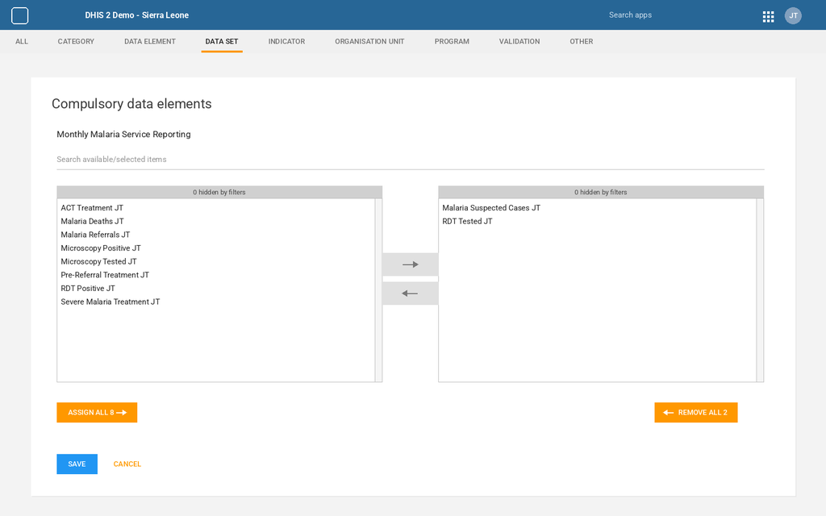

12345

**Figure 9.** Two data elements marked compulsory. *This picture was drawn for the guide to show what the screen looks like. Your screen will show your own names and dates.*

1. 1**The data set.** The compulsory list belongs to this data set only.
2. 2**Available data elements.** Everything in the data set that is not compulsory.
3. 3**Arrow buttons.** Move a data element across to make it compulsory.
4. 4**Compulsory data elements.** Only the fields the programme insists on. Keep this list short.
5. 5**SAVE.** Saves the compulsory list.

Step 7: Create Validation Rules

Create rules that identify logically impossible or inconsistent combinations of reported values.

**Examples:**  
RDT Positive ≤ RDT Tested  
Microscopy Positive ≤ Microscopy Tested  
Malaria Deaths ≥ 0

Open: Validation Rules → + New

**Expected result:** DHIS2 can identify reporting inconsistencies when the form is validated.

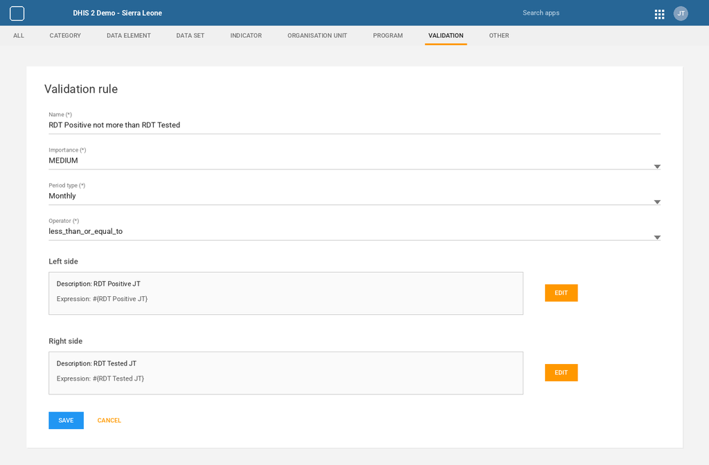

12345678

**Figure 10.** A rule saying RDT Positive cannot be more than RDT Tested. *This picture was drawn for the guide to show what the screen looks like. Your screen will show your own names and dates.*

1. 1**Name (*).** Say what the rule checks, so the message makes sense when it appears.
2. 2**Importance.** Medium is fine for a reporting check.
3. 3**Period type (*).** Monthly, the same as the data set.
4. 4**Operator (*).** less_than_or_equal_to, so the left side may not be greater than the right.
5. 5**Left side.** The value being checked, here RDT Positive.
6. 6**EDIT.** Opens the expression builder, where you pick the data element.
7. 7**Right side.** The value it is compared with, here RDT Tested.
8. 8**SAVE.** Saves the rule.

Step 8: Configure Data Set Sharing

Configure metadata sharing so that the appropriate users and user groups can access the dataset.

Data Set → Sharing / Access

### Check

- Who can view the dataset?
- Who can enter data?
- Who can complete the dataset?
- Which organisation units are available to the users?

**Expected result:** The intended users can access the dataset according to their permissions.

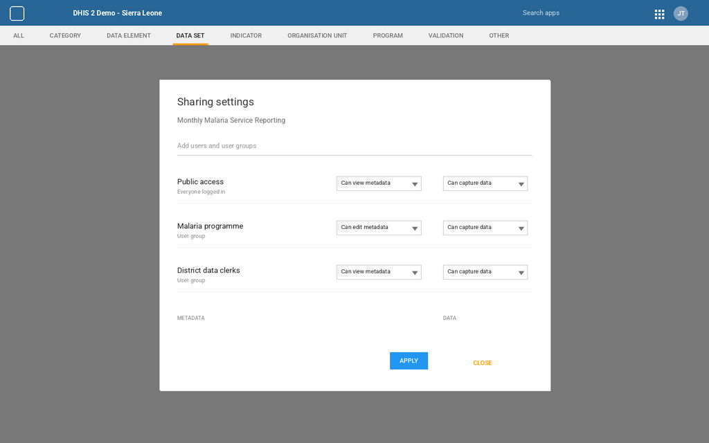

123456

**Figure 11.** Sharing settings for the data set. *This picture was drawn for the guide to show what the screen looks like. Your screen will show your own names and dates.*

1. 1**Sharing settings.** Opened from the row menu of the data set.
2. 2**Add users and user groups.** Type a name to give a group access.
3. 3**Who has access.** Public access first, then each user group you added.
4. 4**Metadata.** Whether they can see or change the form itself.
5. 5**Data.** Whether they can enter data with the form.
6. 6**APPLY.** Saves the sharing settings.

Step 9: Final Review of the Configuration

Review the complete form before deploying it to users.

- Check every data element.
- Check every section.
- Check compulsory fields.
- Check validation rules.
- Check organisation-unit assignment.
- Check user access.
- Test the reporting period.
- Test with realistic and invalid data.
- Test on the devices that users will actually use.

**Expected result:** The complete DHIS2 data-entry form is ready for user acceptance testing.

## Final Checklist

- ☐ Data set created
- ☐ Data elements added to the data set
- ☐ Organisation units assigned
- ☐ Sections created
- ☐ Data elements assigned to sections
- ☐ Compulsory fields configured
- ☐ Validation rules created
- ☐ Sharing and access configured
- ☐ Configuration reviewed before data entry starts